# Using survival analysis to demonstrate the effects of training on employee retention - ScienceDirect

## [Evaluation and Program Planning](https://www.sciencedirect.com/journal/evaluation-and-program-planning)

[Volume 28, Issue 4](https://www.sciencedirect.com/journal/evaluation-and-program-planning/vol/28/issue/4), November 2005, Pages 423-430

# Using survival analysis to demonstrate the effects of training on employee retention

,

https://doi.org/10.1016/j.evalprogplan.2005.07.006[Get rights and content](https://s100.copyright.com/AppDispatchServlet?publisherName=ELS&contentID=S0149718905000637&orderBeanReset=true)

Full text access

## Abstract

In order to thrive, companies are waging war with competitors to hire and retain the most knowledgeable and skilled employees. Personnel with industry experience are the highly valued field generals who will win new business and generate revenue. The cost of acquiring experienced personnel and the cost of losing such personnel is substantial, upwards of $100,000 per person. To remain profitable, companies must retain personnel as long as possible. Training is among the many tactics that have been implemented to increase retention among employees. This article focuses on assessing the impact of a 3-day training course designed to acclimate experienced hires to one company's policies, formal and informal procedures, and pathways to success. A quasi-experimental design, wherein study participants self-selected to attend training, was used to test the hypothesis that training would increase retention and justify the substantial financial investment in training. Attention is given to the benefits of using survival analysis as a data analytic technique applicable for employee retention studies.

## Keywords

Survival analysis

Employee retention

Quasi-experimental design

Employee retention is a concern for many organizations. It is costly to replace personnel, and often the individuals who leave take proprietary knowledge that is impossible to replace. A ripple effect often occurs as well. When employees depart, they impact morale, spur rumors, and often open the door for others to leave the organization.

High employee turnover can have a devastating effect on a company especially if the lost employees are high performers. According to the Saratoga Institute, which specializes in quantitative human resources measurement systems, the average company loses about $1 million with every 10 professional employees who leave (Garger, 1999).

Experienced hires are particularly costly. These individuals have several years of experience practicing their trade for other companies. Their knowledge, insights and industry experience can often lend employers a competitive advantage. Because these individuals are so prized, they receive ongoing job offers, and they are often difficult to assimilate and retain.

In addition to concerns with employee turnover, organizations must also address the fact that the labor shortage is a real phenomenon. The US Bureau of Labor Statistics reports that the growth rate in the labor force has been shrinking steadily and will actually turn negative by 2015 (Fullerton, 1999). The need for high performing personnel amidst a sometimes booming market and a shrinking labor market puts organizations in dire straits when turnover is high. These conditions create an attitude among companies that has reached fervor. So intense is the need to acquire and retain the best personnel, the situation has been dubbed the ‘War for Talent’ (Anders, 2001; Fast Company, 2001).

Why do employees leave? Based on his review of the literature, Ryan (2000) concludes that an employee departs because the current employment proposition is unsatisfactory. Every employment proposition consists of some mixture of tangibles such as pay and benefits, and intangibles such as relationships with colleagues, work/life balance, and trust in management. When the current position is not meeting employee's needs, and an opportunity to join another organization is available where, presumably, the employment proposition is better the employee is apt to leave.

Retention of experienced hires introduces an additional set of variables. Given the investment required to win this prize crew of personnel and the vast array of organizational cultures from which they come, new employees who feel lost, ignored, or inadequately prepared tend to leave quickly. Employees who have been difficult to find in the first place have many available alternatives and leave if they feel uncomfortable (McConnell, 1999).

Although there are several factors that influence the decision to leave an organization, one factor that is linked with the decision to stay is training (Doll, 2000). In 2002, American Businesses invested nearly $54.2 billion dollars on corporate training according to *Training Magazine* (Galvin, 2003). Some of this investment has been shown to impact retention of employees. However, the majority of studies examining the relationship between training and retention have focused on traditional hires and employees. Very little research has examined the role that training plays in the retention of experience hires.

When examining retention among employees, traditional methods include point-in-time analysis to determine retention rates among various employee groups. Analysis of variance or regression are often used to assess the current state of turnover after a set period of time, to determine the effect of an intervention on retention, or even to predict which employee groups and individuals are at risk for leaving. These analytical techniques are useful, but another technique, survival analysis, provides additional information when considering retention or other employment data.

Survival analysis has been widely used and has a long tradition in biomedical research examining the survival of patients following surgery or other medical treatments (Kungl.Vetenskapsakademien, n.d.). In addition, a number of duration models (including survival analysis) have been used in applied studies of employment and unemployment, economics and demography (Heckman and Robb, 1985a, Heckman and Robb, 1985b; Heckman & Singer, 1984).

More recently, Morita, Lee, & Mowday, (1993) described the advantages of using survival analysis for the purpose of assessing employee retention. Taking the advice of Morita et al., the authors of this paper used survival analysis to assess the impact of a 3-day training course, called Transitions, among experienced hires. We hypothesized that the personnel who attended the Transitions training course would remain with the company longer than those who did not attend the course. Additionally, we hypothesized that the return on the investment in training would be substantial enough to justify continued used of the program. While testing these hypotheses, we also demonstrated the practical value of using survival analysis to assess the impact of training.

## 1. Method

### 1.1. Participants

All 3136 personnel included in this study worked for a multi-national company that hires more than 3000 experienced personnel each year. Participants in this study were hired between January 1999 and November 2000. These experienced hires served a variety of functions for the company including accounting, enterprise risk management, technology systems implementation, financial consulting, legal advice and tax consulting. Their educational backgrounds varied widely by major and type of degree. Personnel were hired in countries throughout the world, but the majority came from the United States and Europe with the largest proportions coming from the following countries: United States (38.2%), United Kingdom (14.3%), Canada (4.8%), Germany (3.6%), and France (3.1%). Of the 3136 persons included in the study, 89% (*n*=2799) were managers and 11% (*n*=337) held executive leadership positions. Fifteen percent (*n*=459) attended the Transitions training course, and 92% of attendees were managers. The sample of personnel was representative of annual populations of experienced hires in the recent past.

### 1.2. Procedure

#### 1.2.1. The training intervention

The training intervention, called Transitions, was a 3-day, instructor-led course held at a centralized training center. The average class size was 73 participants with a range from 45 to 108 participants. Eleven courses were conducted during the period of this study.

The course was designed to motivate and enable experienced personnel to take ownership for building a successful career with the firm. Participants were encouraged to attend within 6 months of their hire date; participants self-selected to attend. During the 3-day course, participants self-assessed where they were in the change process as they moved from their old employer to new employer. A large portion of time was dedicated to understanding the complex nature of the company and the factors that make employees successful. To this end, the course focused on the structure of the global organization, the company's strategy, vision, mission and values, global resources, the importance of building internal relationships, and responsibilities for managing profitability.

Evaluations were conducted at the end of each course, requiring participants to provide feedback on the useful and effective aspects of the course, materials and instructors.

#### 1.2.2. Study design

The study is a simple retrospective quasi-experimental design. Experienced hires who chose to attend Transitions between January 1999 and November 2000 were compared to experienced hires who did not attend Transitions during the same period. Three metrics are used to assess impact: (1) whether the study participants stayed or left the company, (2) the length of time in days each study participant remained an employee, and (3) the revenue generated by each employee (see Fig. 1).

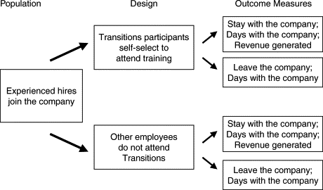

1. [Download: Download full-size image](https://ars.els-cdn.com/content/image/1-s2.0-S0149718905000637-gr1.gif)

Fig. 1. Quasi-experimental study design.

#### 1.2.3. Data collection

Two databases maintained by the company were queried to gather data for this study. The first database contained human resources data such as employee name, employee personnel number, hire date, position by type of work performed, level within the company, pay grade, work location by city, and termination date. The second database contained information about training courses conducted at the company's centralized training facility. From this database, rosters were collected indicating who had attended the Transitions course between January 1999 and November 2000.

#### 1.2.4. Data analysis

Once the two datasets were collected, one from each database, they were merged using the employee personnel number. The data were then structured to accommodate survival analysis techniques. This required computing a variable to quantify the length of time each person stayed with the company. For persons who left the company for voluntary or involuntary reasons, the length of time was computed as the difference between hire date and termination date. For those who remained with the company through the end of the study, the length of time was computed as the difference between hire date and the end-of-study date, the end of November. Two variables were added to the data set: status and attendance. Status indicated whether the study participant terminated employment during the study period, and attendance indicated whether the study participant attended the Transitions course.

Although traditional data analysis methods such as regression, ANOVA or ANCOVA could have been used to analyze the data, we chose to use survival analysis for two reasons. First, survival analysis takes into account the unique nature of employee retention data—the censoring of participants. The dependent variable in retention studies is the length of time a person remains in the organization. For those who leave, this period is fixed. We fail to observe the actual departure date for those who remain with the organization and must set an arbitrary cut-point, usually the date at end of the study, and thus censor our participants. The statistical implication when comparing means using a technique like ANOVA is that the average length of retention among those who remain will be longer. The proportion of participants in each group varies throughout the study period and survival analysis, Cox regression in particular, adjusts the estimates proportionately. The second advantage of using survival analysis is that it graphically represents turnover in daily units. Later, we demonstrate that the survival curves produce a continuous stream of information for the study period while other techniques provide discrete point-in-time displays, typically at the mid-point and end of a study.

Two analytical methods, Kaplan–Meier survival analysis and Cox regression, produce survival curves. The Kaplan–Meier analysis is exceptionally useful for determining the impact of categorical variables, like gender or treatment type, on the dependent variable. Cox regression allows for the use of continuous independent variables, known as covariates, such as age and years of experience. Because we initially considered using continuous variables in our analysis, we used Cox regression. In the end, our final model only contained one independent variable, training, which would have fit nicely in the Kaplan–Meier analysis, but we chose to stay with Cox regression, our original analytic method. To analyze the data, we used the statistical package for social sciences (SPSSs). In addition to Cox regression we conducted a traditional analysis of variance and compared our results to demonstrate the value of using survival analysis.

## 2. Results

To demonstrate the impact of training and to compare statistical techniques, both ANOVA and survival analysis were used to test the hypothesis that a 3-day training course had a positive impact on employee retention. The only persons excluded from analysis were those who temporarily left the employer for reasons such as maternity leave or sabbatical. Because these individuals were not working for the company nor had they terminated employment, they were not considered for this study.

### 2.1. ANOVA

Using a factorial design with status (terminated or employed) and course attendance (yes or no) as the independent variables and length of time in days as the dependent variable, analysis indicated there were significant differences among groups for each independent variable (Attended: *F*=151.29, *p*≤0.001; Status: *F* (1, 3135)=43.21, *p*≤0.001), but not for the interaction of these variables (Interaction: *F* (1, 3125)=0.366, *p*≤0.545). Also by division, it was apparent that turnover for this sample, whether study participants attended training or not, was 20.92% at the end of the study period. Conversely, retention was 79.08% (see Table 1).

Table 1. Descriptive statistics from ANOVA

| Training | Status | Mean days | SD | N |
| --- | --- | --- | --- | --- |
| Did not attend | Remained | 303.38 | 212.44 | 2101 |
|  | Terminated | 209.26 | 179.52 | 576 |
|  | Total | 283.13 | 209.38 | 2677 |
| Attended | Remained | 456.72 | 154.10 | 379 |
|  | Terminated | 378.46 | 152.56 | 80 |
|  | Total | 443.08 | 156.51 | 459 |
| Total | Remained | 326.81 | 211.89 | 2480 |
|  | Terminated | 229.90 | 184.85 | 656 |
|  | Total | 306.54 | 210.23 | 3136 |

Fig. 2 depicts group differences among participants who attended training and those who did not by termination status. Regardless of termination status, by the end of the study participants who attended training stayed with the company 160 days longer (443 vs. 283 days) on average than those who did not attend (see Fig. 2).

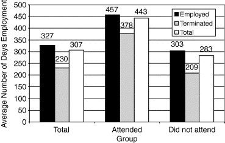

1. [Download: Download full-size image](https://ars.els-cdn.com/content/image/1-s2.0-S0149718905000637-gr2.jpg)

Fig. 2. Length of time employed by attendance and termination status.

### 2.2. Survival analysis

Like the ANOVA, survival analysis indicated that course attendance had a significant impact upon the length of time an employee stayed with the client. The test included only one covariate (independent variable), ‘attendance’. The overall model yielded a −2 log likelihood value equaling 9428.76. The *χ*<sup>2</sup> value was significant, *χ*<sup>2</sup>(1)=35.73, *p*<0.001. With only one covariate in the model, the significant *χ*<sup>2</sup> value is sufficient to indicate the substantial impact of training. If more than one covariate was used, a Wald statistic would be included for each. As expected due to the significant *χ*<sup>2</sup> value and only one covariate in the model, the Wald statistic was also significant *W*=30.20, *p*<0.001.

The significant *χ*<sup>2</sup> indicates training significantly impacted retention and the survival curves in Fig. 3 demonstrate that the impact of training was positive. Those who attended training stayed with the company longer than those who did not attend (see Fig. 3).

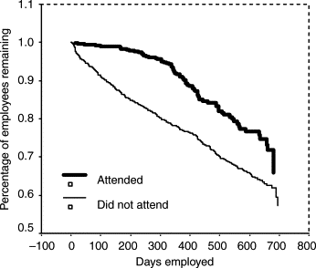

1. [Download: Download full-size image](https://ars.els-cdn.com/content/image/1-s2.0-S0149718905000637-gr3.gif)

Fig. 3. Retention curves showing the impact of training.

### 2.3. Advanced interpretation

There is often a need to assess retention according to benchmarks. Four common benchmarks are (a) the retention percentage at a point in time (for example, after 2 years of employment), (b) the retention rate overtime, (c) the length of time required to reach a specific retention percentage such as 80% retention, and in this case (d) the impact of training on the amount of time and revenue gained by sending an employee to training. Each of these four metrics is discussed in more detail below.

The retention percentage is a point-in-time measure and is most often computed by dividing the number who have terminated by the number employees who were hired for a given period multiplied by 100 and subtracted from 100%. According to the ANOVA results, the retention percentage is 79.08%. From the survival analysis, the percentage is 79.69. The slight difference between these figures is due to some missing data in the survival analysis, which caused two cases to drop from the analysis.

By breaking down the retention percentage by group, the impact of training is revealed. From the ANOVA, it is easy to determine that the percentage for those who attended training is 82.57 and 78.48% for those who did not attend. Thus, the retention rate is slightly better for those who have attended training.

The retention rate is determined by the change in retention over time. From the ANOVA results, the rate is computed at two points, time zero when the rate is 100% and at the end of the study when the rate is 79.08%. Thus, over a 2-year period, the company can expect to lose more than 20% of its employees regardless of whether they attend training or not. If they attended training, the retention rate is 82.57%, and if they did not attend training, the retention rate is 78.48%. This measure of retention for ANOVA is exactly the same as the retention percentage mentioned above because retention is only assessed at the end of the study. Of course, it can be assessed at different times throughout the study using ANOVA, but this requires extra planning and analysis for each point in time.

Using survival analysis, the retention rate is computed automatically for each group and for every unit of time in the study, which in this case is days. The survival curves depict the changing retention rate. This is an especially important feature of survival analysis because retention rates are not necessarily constant over time. Fig. 4 demonstrates the changing rate of retention among participants who attended training and the constant rate among those who did not attend training. For the group that attended training, the retention rate was 95% during the first year (5% turnover) and 80% during the second year (20% turnover). The retention rate was 80% each year (20% turnover) for the group that did not attend training (see Fig. 4).

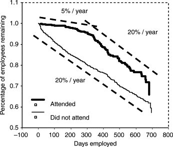

1. [Download: Download full-size image](https://ars.els-cdn.com/content/image/1-s2.0-S0149718905000637-gr4.gif)

Fig. 4. Changing rates of retention for each retention curve.

It is also easy to quantify the differences between groups at any given time using survival analysis, whereas ANOVA requires repeated computation of results at set time intervals. Survival curves facilitate computing group differences in retention rates. For example, the difference between the retention curves is 12% at 500 days. Thus, after 500 days, the retention rate is 12% higher for the training group (see Fig. 5).

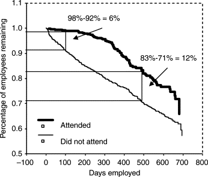

1. [Download: Download full-size image](https://ars.els-cdn.com/content/image/1-s2.0-S0149718905000637-gr5.gif)

Fig. 5. Computing differences in retention rates between groups.

The length of time to reach a certain retention percentage is another common retention metric, and the benchmark is often set at 80% retention for a 2-year period. ANOVA and survival analysis both demonstrate that the company reached 80% retention after nearly 2 years. Using survival curves, it is easier to visualize and predict when a sample will reach the 80% benchmark. For example, the group that did not attend training reached the 80% benchmark after 300 days, whereas the group that attended training did not reach the benchmark until 550 days. If all other factors were equal, we would conclude that training increases retention by 250 days (see Fig. 6).

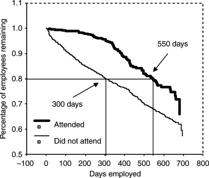

1. [Download: Download full-size image](https://ars.els-cdn.com/content/image/1-s2.0-S0149718905000637-gr6.gif)

Fig. 6. Comparison between groups of the days required to reach a benchmark of 80% retention.

### 2.4. Cost benefit analysis

The results indicate that training had a positive impact on retention rates and thus the length of time employees stay. Several factors affect the amount of revenue an employee generates, and the length of time is a key factor. Other factors include level (executive or manager), the percentage of client work rather than administrative work completed, and the billing rate of each employee. Additional revenue was generated by the group that attended training, assuming that these individuals (*n*=379) stayed employed 250 days longer than those who did not attend training (see Table 2). The equation for computing revenue generated by each employee level is as follows:$Revenue=(billingrate)×(percentageofbillablehours)×(hoursworkedperday)×(ratioofworkingdaysperweek)×(additionaldaysemployed)$

Table 2. Revenue analysis per type of employee

| Employee type | Billing rate per hour<sup>a</sup> | Percentage of billable work | Hours worked per day | Ratio of working days per week | Additional days employed | Total revenue generated per person |
| --- | --- | --- | --- | --- | --- | --- |
| Executive | $500 | 25 | 8 | 5/7 | 250 | $178,571 |
| Manager | $300 | 50 | 8 | 5/7 | 250 | $214,286 |

**a**

Approximate billing rates used for demonstration purposes. Actual rates are proprietary.

Of the 379 persons who attended training and did not leave, 8% (30) were executives and 92% (349) were managers. Among managers, the additional revenue gained was $74.8 million, and among executives, the revenue gained was $5.4 million. The overall revenue gained among this sample was $80.2 million.

The cost of attending training was considerable. Two factors comprised the overall cost of training: tuition and expenses. Tuition was based on billing rates for each individual. Tuition cost was $12,000 per person for executives and $7200 per person for managers. Additional costs included $750 dollars for on-site expenses for 3 days, and $2000 on average for air travel to and from the training facility with expenses applied equally to executives and managers (see Table 3).

Table 3. Cost analysis per type of employee

| Employee type | Tuition | On-site expenses | Average travel expenses | Individual total | Group total |
| --- | --- | --- | --- | --- | --- |
| Executive | $12,000 | $750 | $2000 | $14,750 | $442,500 |
| Manager | $7200 | $750 | $2000 | $9950 | $3,472,550 |

Table 4. Cost benefit analysis summary

| Employee type | Individual training costs | Individual revenue gained (250 days) | Group training costs | Group revenue gained (250 days) | Benefit to cost ratio |
| --- | --- | --- | --- | --- | --- |
| Executive | $14,750 | $178,571 | $442,500 | $5,357,130 | 12.11 |
| Manager | $9950 | $214,286 | $3,472,550 | $74,785,814 | 21.54 |

## 3. Discussion

Support for the study hypothesis is offered with some hesitation because the design was non-randomized. Groups self-selected to attend or not attend training. Participants may have come from offices that had sufficient funds to send personnel to training. Participants may have had an interest in training that led to increased commitment to the company. For these and many unknown reasons that were not controlled through random assignment to condition, a conclusion that training increased retention and revenue may be biased. However, until a randomized design can be conducted with this population, the results indicate that there is a strong relationship between training, retention, and revenue.

Because many researchers are unlikely to employ an experimental design in a corporate setting, we have some suggestions for improving upon the quality of this and future designs. First, as participants enter the training condition, match them against non-trainees who have similar personal and professional characteristics. Second, use propensity scores based on personal and professional characteristics to match personnel. Third, estimate the bias or differences between groups and use the estimate as a covariate in the analysis. Fourth, examine with more scrutiny the dynamic changes in both trained and untrained groups as participants exit. Those who leave early may be substantially different than those who leave late. Fifth, as an alternative design, use random assignment with a delayed control group. When a population of attendees becomes available, assign half to attend and delay attendance for the other half by 6–12 months. For more information about non-experimental designs and drawing causal inferences see Shadish, Cook, and Campbell (2002).

The secondary purpose of this article is to illustrate that a non-traditional statistical technique called survival analysis (Cox regression) provides useful information above and beyond the more traditional analytical technique of ANOVA. In fact, the benefits of using survival analysis instead of ANOVA are numerous. First, survival analysis allows for point-in-time retention analysis similar to ANOVA. However, an unlimited number of point-in-time analyses are available using survival analysis, while ANOVA requires re-analysis for every point-in-time estimate. Second, as with ANOVA, significance testing with survival analysis allows users to determine the statistical impact of independent variables such as training attendance. Third, it is easier to visualize the impact of training using survival curves rather than point-in-time bar graphs produced by ANOVA. Fourth, it is easier to determine when a sample reaches a retention benchmark, such as 20% turnover, by examining the survival curves.

Although survival analysis is most often used in medical studies to determine length of survival after the onset of a disease, it has many practical uses in other fields. It is applicable in any study in which time-to-event data are used. To gain the benefits of survival analysis, it is imperative to collect details of three variables, start date, end date, and status. The end date may be a termination date or an end-of-study date. Status is a dichotomous variable, employed or terminated. In other studies, status indicates whether a participant is still part of the study or has terminated.

Because survival analysis is not often used to describe retention rates or determine the impact of training, sponsors, clients and other stakeholders may be wary of the technique or require additional assistance when interpreting and acting on the results. A couple recommendations are offered here when using this technique in the human capital arena.

First, use the appropriate technique. Clients are often very comfortable with simple descriptive statistics such as frequencies or means. And some may even be open to the more traditional use of ANOVA as described above. However, the use of a more advanced statistical technique such as survival analysis may be the more appropriate technique and thus worth the effort to employ. In practice, it is more advantageous to employ the appropriate statistic first and then determine the most appropriate way to explain the result than to use a more simplistic technique and be unable to demonstrate effects. This approach is in line with standard A8 of the Program Evaluation Standards—2nd Edition (1994), which states that quantitative information should be appropriately and systematically analyzed so that the evaluation questions are effectively answered. The authors of this article believe that use of the most appropriate and powerful statistic is more than warranted even when stakeholders do not fully understand its theoretical basis or its detailed computations.

Second, help the client understand the results. Regardless of the complex or simplistic nature of the analysis, it is essential to communicate the results effectively by speaking the language of the client. That is, use terms that are easily understood or easy to explain to the client. Deep discussion of the statistical techniques will not resonate with most professionals in the fields of training, human resources, or business. Focus on familiar impact measures such as percentage improvements, increased retention time, and return on investment. The complex terms and techniques associated with significance testing in this study are not appropriate to present to stakeholders. However, the results contained in the tables and graphs are common metrics that are easy to understand.

Based on our own recommendations, we presented the graphs and tables contained in this article to our stakeholder, the program manager for the Transitions course with the following conclusion: training positively impacts employee retention and subsequent revenue, with the return on investment ranging from $12 to $21 per person depending on level. Because we used appropriate statistics and more importantly clear and easy to understand graphs and tables, the stakeholder is pursuing our recommendation to send all future experienced hires to the Transition program.

## References

1. Anders, 2001

   G. Anders

   Talent bank: Thomas Weisel turned his former firm, montgomery securities, into an investment-banking powerhouse. Now he's building a new firm—and gaining ground on some of the most established names on wall street

   Fast Company, 44 (2001), pp. 142-148

   Google Scholar
2. Doll, 2000

   T.M. Doll

   View from Washington: Does employer-sponsored training improve retention?

   Journal of Compensation and Benefits, 16 (2000), pp. 35-38

   [Google Scholar](https://scholar.google.com/scholar_lookup?title=View%20from%20Washington%3A%20Does%20employer-sponsored%20training%20improve%20retention&publication_year=2000&author=T.M.%20Doll)
3. Fast Company, 2001

   Fast Company

   War for talent II: Seven ways to win: McKinsey and Co. surveyed 6,900 senior executives and young managers from 56 companies to figure out the secrets of a smart plan to win the battle for great people

   Fast Company, 42 (2001), pp. 98-99

   Google Scholar
4. Fullerton, 1999

   H.N. Fullerton

   Labor force participation: 75 years of change, 1950–98 and 1998–2025

   Monthly Labor Review, 122 (1999), pp. 3-12

   [View in Scopus](https://www.scopus.com/inward/record.url?eid=2-s2.0-0039850979&partnerID=10&rel=R3.0.0)[Google Scholar](https://scholar.google.com/scholar_lookup?title=Labor%20force%20participation%3A%2075%20years%20of%20change%2C%20195098%20and%2019982025&publication_year=1999&author=H.N.%20Fullerton)
5. Heckman and Robb, 1985a

   J.J. Heckman, R. Robb

   Alternative methods for evaluating the impact of interventions: An overview

   Journal of Econmometrics, 30 (1985), pp. 239-267

   [View PDF](https://www.sciencedirect.com/science/article/pii/0304407685901393/pdf?md5=e5043903a7feab176e3e58d60ab3ef17&pid=1-s2.0-0304407685901393-main.pdf)[View article](https://www.sciencedirect.com/science/article/pii/0304407685901393)[View in Scopus](https://www.scopus.com/inward/record.url?eid=2-s2.0-0001206898&partnerID=10&rel=R3.0.0)[Google Scholar](https://scholar.google.com/scholar_lookup?title=Alternative%20methods%20for%20evaluating%20the%20impact%20of%20interventions%3A%20An%20overview&publication_year=1985&author=J.J.%20Heckman&author=R.%20Robb)
6. Heckman and Robb, 1985b

   J.J. Heckman, R. Robb

   Alternative methods for evaluating the impact of interventions

   J.J. Heckman, B. Singer (Eds.), Longitudinal analysis of labor market data, Econometric society monographs series, Cambridge University Press, Cambridge (1985), pp. 156-245

   [Google Scholar](https://scholar.google.com/scholar_lookup?title=Alternative%20methods%20for%20evaluating%20the%20impact%20of%20interventions&publication_year=1985&author=J.J.%20Heckman&author=R.%20Robb)
7. Heckman and Singer, 1984

   J.J. Heckman, B. Singer

   A method of minimizing the impact of distributional assumptions for duration data

   Econometrica, 52 (1984), pp. 271-320

   [Crossref](https://doi.org/10.2307/1911491)Google Scholar
8. Kungl.Vetenskapsakademien, n.d.

   Kungl.Vetenskapsakademien: The Royal Swedish Academy of Sciences (n.d.). *The scientific contributions of James Heckman and Daniel McFadden*. Retrieved November 18, 2004 from http://www.econ.umn.edu/graduate/nobel.pdf

   Google Scholar
9. Galvin, 2003

   Galvin, T. (2003). Industry study 2003. *Training Magazine*. Retrieved December 11, 2003, from http://www.trainingmag.com/training/feature_display.jsp?vnu_content_id=1988738.

   Google Scholar
10. Garger, 1999

    E.M. Garger

    Holding on to high performers: A strategic approach to retention

    Compensation and Benefits Management, 15 (1999), pp. 10-17

    [Google Scholar](https://scholar.google.com/scholar_lookup?title=Holding%20on%20to%20high%20performers%3A%20A%20strategic%20approach%20to%20retention&publication_year=1999&author=E.M.%20Garger)
11. Morita et al., 1993

    J.G. Morita, T.W. Lee, R.T. Mowday

    The regression-analog to survival analysis: A selected application to turnover research

    Academy of Management Journal, 36 (6) (1993), pp. 1430-1463

    Google Scholar
12. McConnell, 1999

    C. McConnell

    Staff turnover: Occasional friend, frequent foe, and continuing frustration

    The Healthcare Manager, 18 (1999), pp. 1-13

    [View in Scopus](https://www.scopus.com/inward/record.url?eid=2-s2.0-0033182998&partnerID=10&rel=R3.0.0)[Google Scholar](https://scholar.google.com/scholar_lookup?title=Staff%20turnover%3A%20Occasional%20friend%2C%20frequent%20foe%2C%20and%20continuing%20frustration&publication_year=1999&author=C.%20McConnell)
13. Ryan, 2000

    C. Ryan

    Employee retention—what can the benefits professional do?

    Employee Benefits Journal, 25 (2000), pp. 22-28

    [View in Scopus](https://www.scopus.com/inward/record.url?eid=2-s2.0-0034050914&partnerID=10&rel=R3.0.0)[Google Scholar](https://scholar.google.com/scholar_lookup?title=Employee%20retentionwhat%20can%20the%20benefits%20professional%20do&publication_year=2000&author=C.%20Ryan)
14. Shadish et al., 2002

    W.R. Shadish, T.D. Cook, D.T. Campbell

    Experimental and quasi-experimental designs for generalized causal inference, Houghton-Mifflin, Boston (2002)

    Google Scholar

- 2022, Evaluation and Program Planning

- 2018, Child Abuse and Neglect

- 2012, Journal of Substance Abuse Treatment

- 2024, Journal of Human Resources in Hospitality and Tourism

- 2023, International Journal of Professional Business Review

- 2017, Agricultural and Food Economics

[View Abstract](https://www.sciencedirect.com/science/article/abs/pii/S0149718905000637)

Copyright © 2005 Published by Elsevier Ltd.

  Aurora Brønstad

  Yangyang Chen, …, Leon Zolotoy

  Siddharth S. Karanth, …, María E. Fernández

### Social Media

[figure not shown]

[View PDF](https://www.sciencedirect.com/science/article/pii/S0149718905000637/pdf)